# Sinais degrau e impulso unitário em tempo discreto

Renato Naville Watanabe

## Sinal impulso unitário

É o sinal mais simples que existe em tempio discreto. Para representá-lo, usamos a letra $\delta$, e é definido da seguinte maneira:

$$\delta[n] = \left\{\begin{array}{cc}1& ,n = 0 \\ 0& ,c.c \end{array}\right. $$

O seu gráfico é o seguinte:

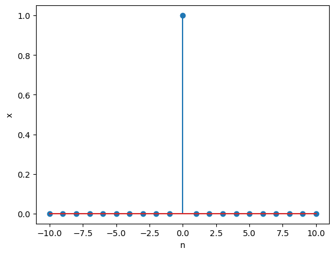

Para obter um impulso unitário em outra posição que não $n=0$, basta atrasarmos (ou adiantarmos) o sinal $\delta[n]$. Se queremos que o sinal seja 1 em $n=k$, basta fazermos $\delta[n-k]$.

Por exemplo, se queremos um impulso unitário em $n=2$, fazemos $\delta[n-2]$.

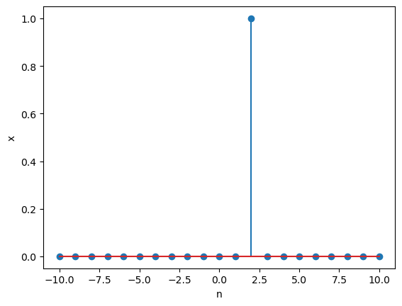

## Sinal degrau

Outro sinal que usaremos bastante é o sinal degrau de tempo discreto. Esse sinal é sempre igual a 1 para $n\geq 0$. Para esse sinal usaremos a letra $u$:

$$u[n] = \left\{\begin{array}{cc}1& ,n \geq 0 \\ 0& ,c.c \end{array}\right. $$

O seu gráfico é mostrado abaixo:

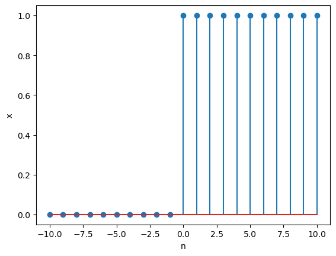

Os sinais degrau e impulso unitário em tempo discreto estão bastante relacionados. O sinal impulso unitário é o sinal degrau subtraido do mesmo sinal degrau atrasado de 1 passo.

$$\delta[n] = u[n] - u[n-1]$$

## Exercícios

**1)** Faça o gráfico dos seguintes sinais:

a) $x_1[n]=u[n] - u[n-3]$

b) $x_2[n] = u[n] - 2u[n-3]+u[n-4]$

c) $x_3[n] = nu[n]-2(n-1)u[n-1]+(n-3)u[n-3]$

**2)** Faça o gráfico dos seguintes sinais:

a) $x_1[n] = u[n] - \delta[n-3]-u[n-4]$

b) $x_2[n] = nu[n] - nu[n-5] + 3\delta[n-2]$

c) $x_3[n] = 2\delta[n-1] - 4\delta[n-3]$

**3)** Considere o seguinte sinal de tempo discreto:

$$x[n] = 1-\displaystyle\sum_{k=2^\infty}\delta[n-2-k] $$

Determine os valores dos números inteiros $M$ e $n_0$ para escrever $x[n]$ na forma:

$$x[n]=u[Mn-n_0] $$

**4)** Considere o seguinte sinal:

$$x[n] = 0.5^{n-1}(u[n+2]- u[n-8])$$

Encontre $a$ e $b$ na expressão abaixo:

$$x[n-k] = \left\{\begin{array}{cc}0.5^{n-k-1}&\text{ , se } a< k < b \\ 0& \text{ , c.c.} \end{array}\right. $$

## Referências

- Oppenheim, M. e Willsky, S., Sistemas e Sinais, 2010
- Ulaby, FT e Yagle, AE, Signals & Systems: Theory and Applications, 2018, ss2.eecs.umich.edu